# report_of_transformer

## Transformer-based AMC

If you want to see Python source codes, please click:

https://github.com/louisinhit/transformer_based_AMC.git

Here only tests the performance of this transformer-based network (no train):

Testset is selected evenly from full dataset, original set has 24 *26* 4096 samples (24 classes, 26 kinds of SNR and 4096 samples each), trainset has 24 *26* (4096-512) and testset has 24 *26* 512 pieces **(train : test = 7:1)**.

### The result accuracy curve is posted here first:

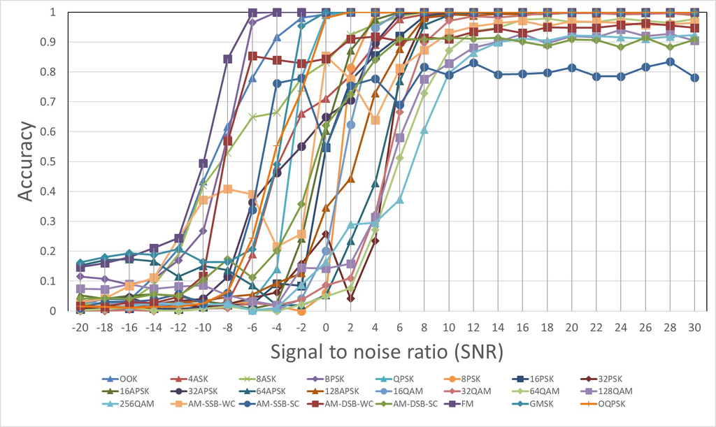

```python
# import packets.
import torch
import torch.optim as optim
import torch.nn.functional as F
import sys, os
import numpy as np
import torch.nn as nn
import h5py
import torch.utils.data as utils
from torch.utils.data.sampler import SubsetRandomSampler
import random
import matplotlib.pyplot as plt
import seaborn as sn
import pandas as pd
import sklearn.metrics as skm
```

```python
# functions will be used.

def output_s(message, save_filename):
    print (message)
    with open(save_filename, 'a') as out:
        out.write(message + '\n')

def test(testset):
    model.eval()
    test_loss = 0
    correct = 0
    total = 0
    test_loader = utils.DataLoader(testset, batch_size=32)
    predict = []

    with torch.no_grad():
        for data, target in test_loader:
            data, target = data.cuda(), target.cuda()
            output = model(data)
            target = target.squeeze_()
            _, predicted = torch.max(output.data, 1)
            total += target.size(0)
            correct += (predicted == target).sum().item()
            predict.extend(predicted)
        message = ('\nTest set: SNR : {} , Accuracy: {}/{} ({:.3f}%)\n'.format(
            snr, correct, total, 100. * correct / total))
        output_s(message, 'test_cm_array/test_msg.txt')
        return correct / total, predict


def create_label():

    mods = range(24)
    mo = []
    for m in mods:
        mo.append([m] * 4096 * 26)

    mo = np.expand_dims(np.hstack(mo), axis=1)
    print (np.shape(mo))

    snr = []
    for m in range(24):
        for i in range( -20, 32, 2 ):
            snr.append([i] * 4096)

    return mo, np.hstack(snr)


def get_set():

    x = h5py.File("GOLD_XYZ_OSC.0001_1024.hdf5", 'r+')
    labels, snrs = create_label()
    # load the test set idx
    with open('test_idx_all.txt') as f:
        lines = f.read().splitlines()
    test_idx = [int(float(i)) for i in lines]

    data_test0 = []
    for it in test_idx:
        data_test0.append(x['X'][it, :, :])

    data_test0 = np.asarray(data_test0)
    label_test0 = labels[test_idx, :]
    snr_test = snrs[test_idx]

    return data_test0, label_test0, snr_test
```

```python
data_test0, label_test0, snr_test = get_set()
cr = []
fm = []
cm_idx = ['OOK','4ASK','8ASK','BPSK','QPSK','8PSK','16PSK','32PSK','16APSK','32APSK',
          '64APSK','128APSK','16QAM','32QAM','64QAM','128QAM','256QAM','AM-SSB-WC',
          'AM-SSB-SC','AM-DSB-WC','AM-DSB-SC','FM','GMSK','OQPSK']
```

```
(2555904, 1)
```

```python
# import model
device = torch.device("cuda")
model = torch.load('saved_model/new.r_d_64_h_2_t_LSTM_ksize_8_level_2_n_2_lr_0.0001_dropout_0.01.pt')
model.to(device)
```

### codes below start to test classifier vs per snr.

```
Test set: SNR : -20 , Accuracy: 519/12288 (4.224%)

snr -20 finished, test acc: 4.2 %

[0.021484375, 0.00390625, 0.0234375, 0.115234375, 0.009765625, 0.01953125, 0.005859375, 0.01171875, 0.052734375, 0.03125, 0.15234375, 0.017578125, 0.033203125, 0.0, 0.001953125, 0.07421875, 0.017578125, 0.029296875, 0.009765625, 0.017578125, 0.041015625, 0.146484375, 0.162109375, 0.015625]
```

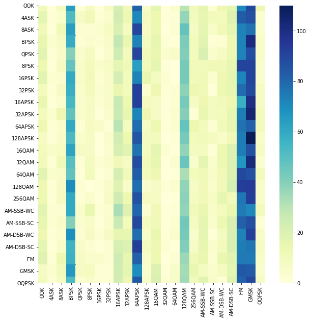

```
Test set: SNR : -18 , Accuracy: 553/12288 (4.500%)

snr -18 finished, test acc: 4.5 %

[0.041015625, 0.01171875, 0.0234375, 0.107421875, 0.0078125, 0.009765625, 0.0078125, 0.009765625, 0.041015625, 0.041015625, 0.169921875, 0.013671875, 0.0234375, 0.0, 0.005859375, 0.072265625, 0.01171875, 0.041015625, 0.03125, 0.013671875, 0.04296875, 0.16015625, 0.1796875, 0.013671875]
```

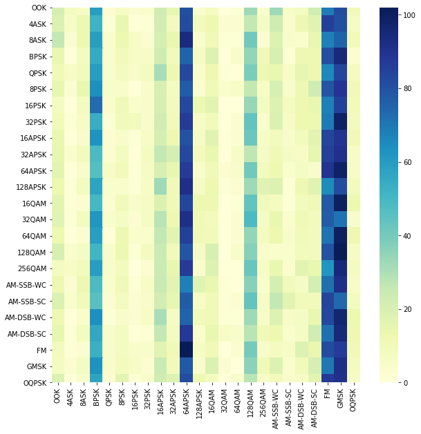

```
Test set: SNR : -16 , Accuracy: 625/12288 (5.086%)

snr -16 finished, test acc: 5.1 %

[0.037109375, 0.017578125, 0.033203125, 0.087890625, 0.009765625, 0.017578125, 0.0078125, 0.009765625, 0.05078125, 0.044921875, 0.173828125, 0.015625, 0.025390625, 0.00390625, 0.01171875, 0.08984375, 0.015625, 0.083984375, 0.03125, 0.029296875, 0.041015625, 0.1796875, 0.193359375, 0.009765625]
```

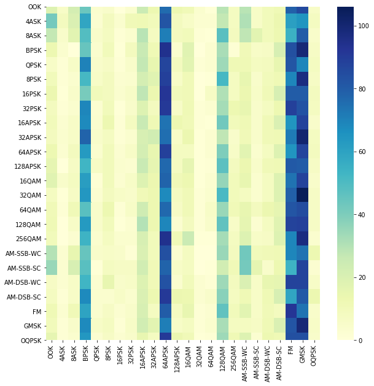

```
Test set: SNR : -14 , Accuracy: 722/12288 (5.876%)

snr -14 finished, test acc: 5.9 %

[0.11328125, 0.0234375, 0.087890625, 0.107421875, 0.017578125, 0.01171875, 0.0078125, 0.009765625, 0.056640625, 0.01953125, 0.166015625, 0.021484375, 0.01953125, 0.0, 0.001953125, 0.07421875, 0.02734375, 0.111328125, 0.037109375, 0.02734375, 0.056640625, 0.2109375, 0.1875, 0.013671875]
```

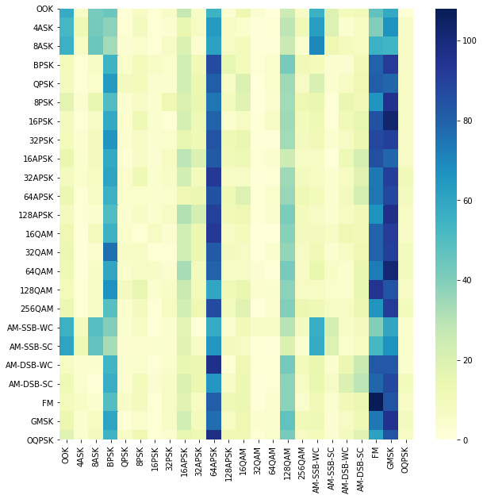

```
Test set: SNR : -12 , Accuracy: 962/12288 (7.829%)

snr -12 finished, test acc: 7.8 %

[0.208984375, 0.03515625, 0.189453125, 0.169921875, 0.005859375, 0.017578125, 0.005859375, 0.025390625, 0.048828125, 0.033203125, 0.115234375, 0.029296875, 0.0234375, 0.001953125, 0.0, 0.08203125, 0.0234375, 0.244140625, 0.056640625, 0.046875, 0.05078125, 0.244140625, 0.20703125, 0.013671875]
```

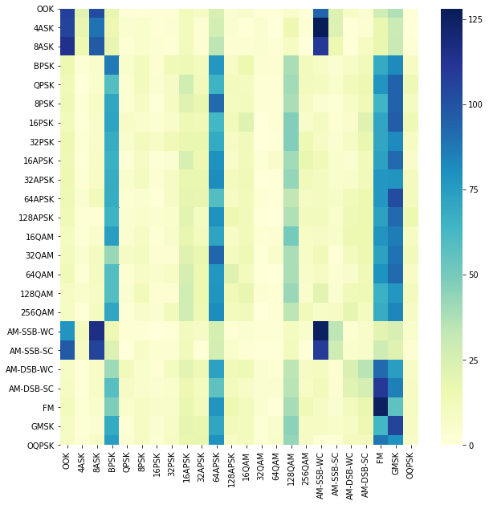

```
Test set: SNR : -10 , Accuracy: 1482/12288 (12.061%)

snr -10 finished, test acc: 12.1 %

[0.43359375, 0.015625, 0.419921875, 0.267578125, 0.01171875, 0.017578125, 0.013671875, 0.01171875, 0.033203125, 0.041015625, 0.150390625, 0.033203125, 0.021484375, 0.0078125, 0.0078125, 0.0859375, 0.021484375, 0.37109375, 0.025390625, 0.1171875, 0.103515625, 0.494140625, 0.1640625, 0.025390625]
```

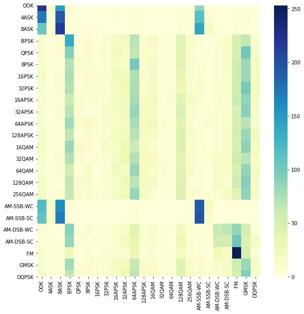

```
Test set: SNR : -8 , Accuracy: 2345/12288 (19.084%)

snr -8 finished, test acc: 19.1 %

[0.6171875, 0.029296875, 0.529296875, 0.583984375, 0.025390625, 0.0234375, 0.01953125, 0.0234375, 0.021484375, 0.115234375, 0.13671875, 0.046875, 0.0234375, 0.009765625, 0.015625, 0.052734375, 0.0234375, 0.408203125, 0.060546875, 0.568359375, 0.173828125, 0.84375, 0.1640625, 0.064453125]
```

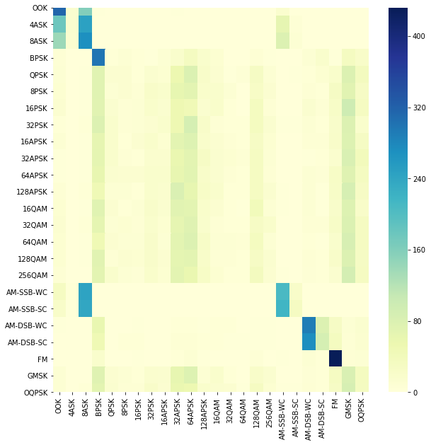

```
Test set: SNR : -6 , Accuracy: 3294/12288 (26.807%)

snr -6 finished, test acc: 26.8 %

[0.779296875, 0.189453125, 0.6484375, 0.96484375, 0.033203125, 0.029296875, 0.0234375, 0.04296875, 0.0078125, 0.36328125, 0.0859375, 0.0546875, 0.001953125, 0.02734375, 0.00390625, 0.033203125, 0.001953125, 0.390625, 0.337890625, 0.853515625, 0.111328125, 0.998046875, 0.20703125, 0.244140625]
```

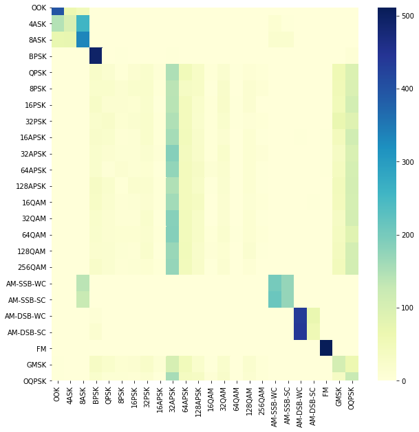

```
Test set: SNR : -4 , Accuracy: 4141/12288 (33.700%)

snr -4 finished, test acc: 33.7 %

[0.916015625, 0.482421875, 0.6640625, 1.0, 0.140625, 0.015625, 0.091796875, 0.0625, 0.025390625, 0.462890625, 0.01953125, 0.09375, 0.00390625, 0.01953125, 0.0, 0.01953125, 0.009765625, 0.21484375, 0.76171875, 0.83984375, 0.201171875, 1.0, 0.490234375, 0.552734375]
```

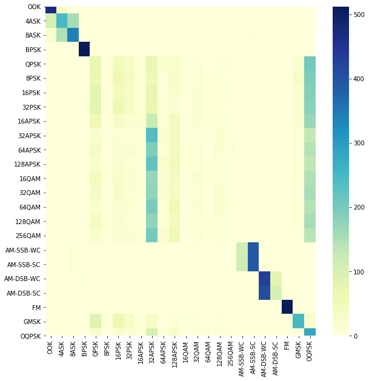

```
Test set: SNR : -2 , Accuracy: 5441/12288 (44.279%)

snr -2 finished, test acc: 44.3 %

[0.98046875, 0.66015625, 0.779296875, 1.0, 0.78125, 0.0, 0.083984375, 0.158203125, 0.2421875, 0.55078125, 0.01953125, 0.126953125, 0.041015625, 0.037109375, 0.021484375, 0.14453125, 0.087890625, 0.2578125, 0.779296875, 0.828125, 0.357421875, 1.0, 0.953125, 0.736328125]
```

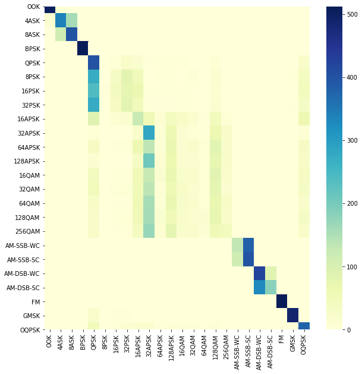

```
Test set: SNR : 0 , Accuracy: 6927/12288 (56.372%)

snr 0 finished, test acc: 56.4 %

[0.9921875, 0.7109375, 0.83203125, 1.0, 0.990234375, 0.060546875, 0.546875, 0.2578125, 0.603515625, 0.6484375, 0.052734375, 0.345703125, 0.201171875, 0.0859375, 0.048828125, 0.142578125, 0.1640625, 0.853515625, 0.546875, 0.84375, 0.62109375, 1.0, 1.0, 0.98046875]
```

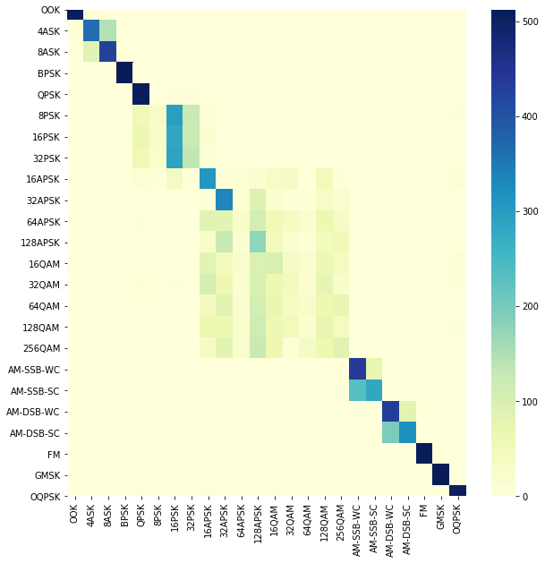

```
Test set: SNR : 2 , Accuracy: 8198/12288 (66.715%)

snr 2 finished, test acc: 66.7 %

[1.0, 0.787109375, 0.923828125, 1.0, 1.0, 0.814453125, 0.771484375, 0.041015625, 0.87109375, 0.705078125, 0.234375, 0.443359375, 0.623046875, 0.109375, 0.076171875, 0.158203125, 0.2890625, 0.775390625, 0.75390625, 0.91015625, 0.724609375, 1.0, 1.0, 1.0]
```

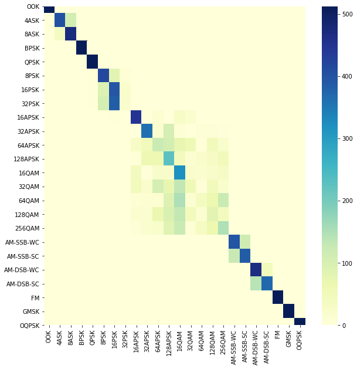

```
Test set: SNR : 4 , Accuracy: 9363/12288 (76.196%)

snr 4 finished, test acc: 76.2 %

[1.0, 0.890625, 0.958984375, 1.0, 1.0, 0.99609375, 0.85546875, 0.234375, 0.974609375, 0.896484375, 0.427734375, 0.728515625, 0.947265625, 0.322265625, 0.271484375, 0.314453125, 0.294921875, 0.638671875, 0.77734375, 0.91796875, 0.83984375, 1.0, 1.0, 1.0]
```

[14 more figures not shown]

```python
plt.rcParams["figure.figsize"]=10,10
accmat = []

for snr in range( -20, 32, 2 ):
    tidx = list(np.where(snr_test == snr))

    data_test = np.squeeze(data_test0[tidx, :, :], axis=0)
    label_test_y = np.squeeze(label_test0[tidx, :], axis=0)

    data_test = torch.from_numpy(data_test).float()
    label_test = torch.from_numpy(label_test_y).long()

    test_set = utils.TensorDataset(data_test, label_test)
    # estimate classes
    acc, t_predict = test(test_set)
    cr.extend([100 * acc])
    print ('snr %d finished, test acc: %.1f %% \n'  % (snr, 100 * acc))

    # F-measure score
    predict = [int(i) for i in t_predict]
    fm.append(list(skm.f1_score(list(np.hstack(label_test_y)), predict, average=None)))

    # plot confusion mat
    conf = np.zeros([24,24])
    for i in range(0, label_test_y.shape[0]):
        conf[label_test_y[i],predict[i]] += 1
    # save acc
    accpersnr = []
    for j in range(24):
        accpersnr.extend([float(conf[j,j]/512.0)])
    accmat.append(accpersnr)
    print (accpersnr)
    #print_mat = pd.DataFrame(conf)
    #print_mat.to_excel(excel_writer = "test_cm_array/conf_mat %d.xlsx" % (snr))
    df_cm = pd.DataFrame(conf,index = cm_idx, columns = cm_idx)
    plt.figure(figsize = (25,25))
    fig = plt.figure()
    sn.heatmap(df_cm, cmap="YlGnBu")
    plt.show()
    fig.savefig('test_CM_pics/confmat %d.jpg' % (snr))
```

### Overall accuracy curve vs SNR.

Note that 512 * 24 = 12288, ensuring all 24 classes can be evenly tested.

Test set: SNR : -20 , Accuracy: 519/12288 (4.224%)

Test set: SNR : -18 , Accuracy: 553/12288 (4.500%)

Test set: SNR : -16 , Accuracy: 625/12288 (5.086%)

Test set: SNR : -14 , Accuracy: 722/12288 (5.876%)

Test set: SNR : -12 , Accuracy: 962/12288 (7.829%)

Test set: SNR : -10 , Accuracy: 1482/12288 (12.061%)

Test set: SNR : -8 , Accuracy: 2345/12288 (19.084%)

Test set: SNR : -6 , Accuracy: 3294/12288 (26.807%)

Test set: SNR : -4 , Accuracy: 4141/12288 (33.700%)

Test set: SNR : -2 , Accuracy: 5441/12288 (44.279%)

Test set: SNR : 0 , Accuracy: 6927/12288 (56.372%)

Test set: SNR : 2 , Accuracy: 8198/12288 (66.715%)

Test set: SNR : 4 , Accuracy: 9363/12288 (76.196%)

Test set: SNR : 6 , Accuracy: 10633/12288 (86.532%)

Test set: SNR : 8 , Accuracy: 11477/12288 (93.400%)

Test set: SNR : 10 , Accuracy: 11762/12288 (95.719%)

Test set: SNR : 12 , Accuracy: 11917/12288 (96.981%)

Test set: SNR : 14 , Accuracy: 11945/12288 (97.209%)

Test set: SNR : 16 , Accuracy: 11975/12288 (97.453%)

Test set: SNR : 18 , Accuracy: 11957/12288 (97.306%)

Test set: SNR : 20 , Accuracy: 11999/12288 (97.648%)

Test set: SNR : 22 , Accuracy: 11980/12288 (97.493%)

Test set: SNR : 24 , Accuracy: 11988/12288 (97.559%)

Test set: SNR : 26 , Accuracy: 11999/12288 (97.648%)

Test set: SNR : 28 , Accuracy: 11996/12288 (97.624%)

Test set: SNR : 30 , Accuracy: 11974/12288 (97.445%)

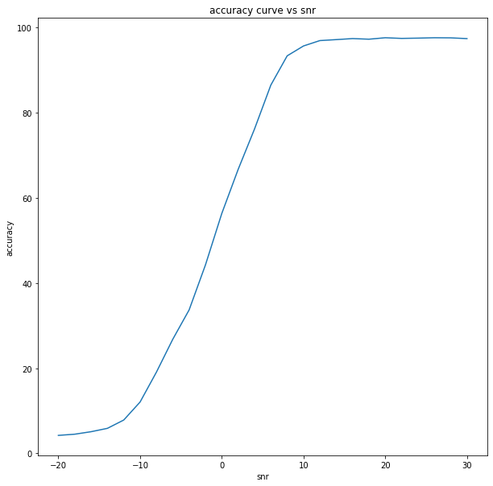

```python
# print overall accuracy curve
plt.plot(range(-20, 32, 2), cr)
plt.title('accuracy curve vs snr')
plt.xlabel('snr')
plt.ylabel('accuracy')
plt.show()
```

### Accuracy curve with each modulation type

The following is the most important diagram shows results.

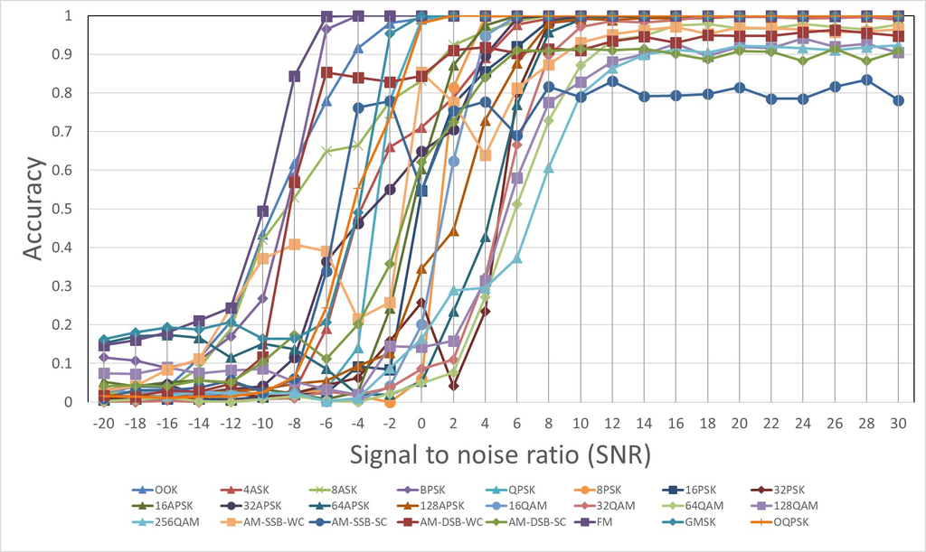

If you want to find more data that supports the graph above pls click: accuracy vs snr table download

## F1 score of test result

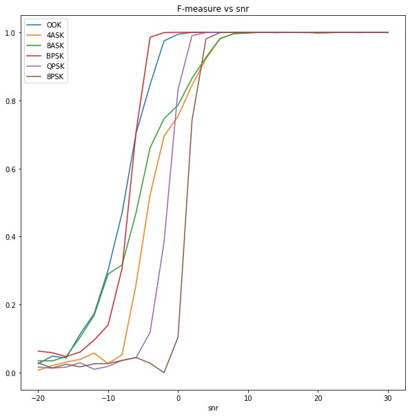

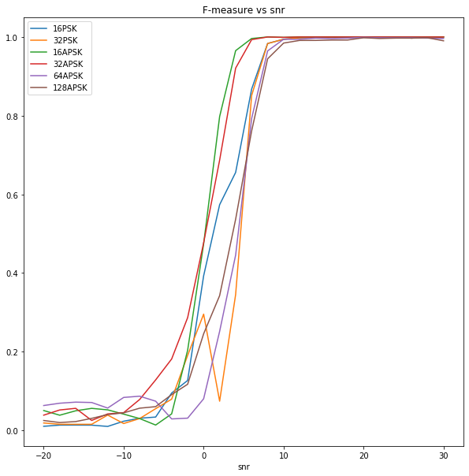

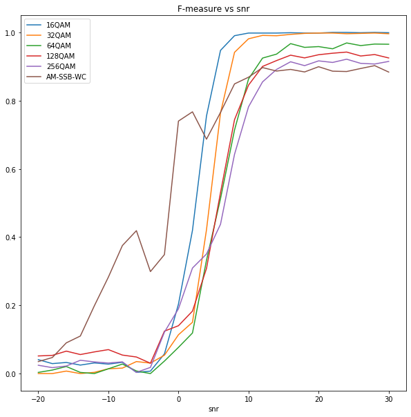

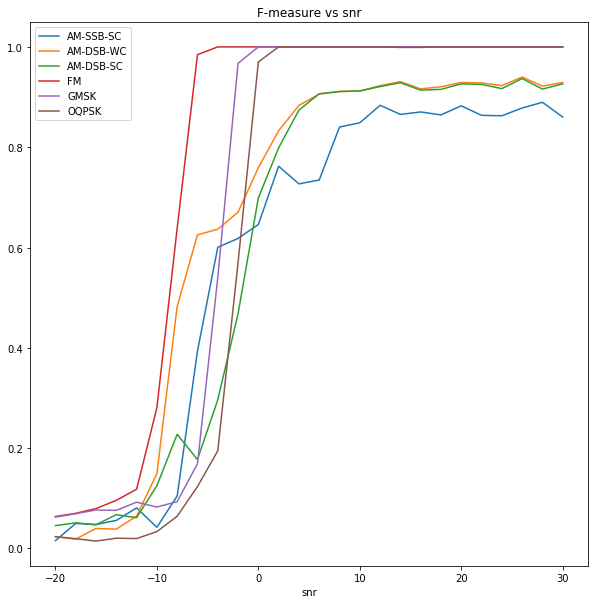

```
No handles with labels found to put in legend.
```

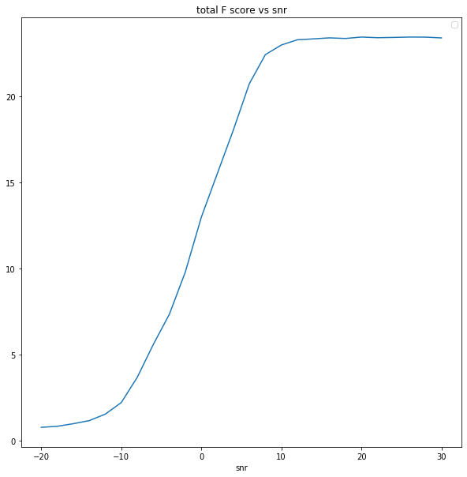

```
[ 0.77401405  0.83436326  0.98431094  1.16359087  1.53958173  2.21311203
  3.68318497  5.5867627   7.33114793  9.79185937 12.974263   15.51009025
 18.03587427 20.72776295 22.41196288 22.9728091  23.27468811 23.32823124
 23.38643457 23.35058771 23.43402659 23.39634757 23.41157831 23.43400264
 23.42920389 23.38406211]
```

```python
fm = np.asarray(fm)
for i in range(4):
    for n in range(6):
        m = i * 6 + n
        plt.plot([[i] for i in range(-20, 32, 2)], fm[:, m], label=cm_idx[m])
        plt.title('F-measure vs snr')
        plt.xlabel('snr')
    plt.legend()
    plt.show()
tt_fs = np.sum(fm, axis=1)
plt.plot([[i] for i in range(-20, 32, 2)], tt_fs)
plt.title('total F score vs snr')
plt.xlabel('snr')
plt.legend()
plt.show()
print (tt_fs)
```